# RAMYA KARANAM-ML- GRADED_ASSIGNMENT

Domain: Automobile Industry

About: There is an automobile company XYZ which aspires to enter the Used-car market by setting up their company locally to give competition to their counterparts.

Challenges: They want to understand the factors affecting the pricing of cars in the market, since those may be very different from the new car market. Essentially, the company wants to know:

• Which variables are significant in predicting the price of a used car?

• How well those variables describe the price of a car

### Here the target variable is the "selling price of a car" so we apply regression algorithms

```python
import pyforest
import warnings
warnings.filterwarnings('ignore')
```

```python
import scipy.stats as st
from sklearn.preprocessing import StandardScaler
```

```python
# Load the dataset
cars_data=pd.read_csv('UsedcarsData.csv')
```

```python
# explore the first 5 rows
cars_data.head()
```

|  | Sales_ID | name | year | selling_price | km_driven | Region | State or Province | City | fuel | seller_type | transmission | owner | mileage | engine | max_power | torque | seats | sold |
| --- | --- | --- | --- | --- | --- | --- | --- | --- | --- | --- | --- | --- | --- | --- | --- | --- | --- | --- |
| 0 | 1 | Maruti Swift Dzire VDI | 2014 | 450000 | 145500 | East | District of Columbia | Washington | Diesel | Individual | Manual | First Owner | 23.4 kmpl | 1248 CC | 74 bhp | 190Nm@ 2000rpm | 5 | Y |
| 1 | 2 | Skoda Rapid 1.5 TDI Ambition | 2014 | 370000 | 120000 | East | New York | New York City | Diesel | Individual | Manual | Second Owner | 21.14 kmpl | 1498 CC | 103.52 bhp | 250Nm@ 1500-2500rpm | 5 | Y |
| 2 | 3 | Honda City 2017-2020 EXi | 2006 | 158000 | 140000 | Central | Illinois | Chicago | Petrol | Individual | Manual | Third Owner | 17.7 kmpl | 1497 CC | 78 bhp | 12.7@ 2,700(kgm@ rpm) | 5 | Y |
| 3 | 4 | Hyundai i20 Sportz Diesel | 2010 | 225000 | 127000 | Central | Illinois | Chicago | Diesel | Individual | Manual | First Owner | 23.0 kmpl | 1396 CC | 90 bhp | 22.4 kgm at 1750-2750rpm | 5 | Y |
| 4 | 5 | Maruti Swift VXI BSIII | 2007 | 130000 | 120000 | East | New York | New York City | Petrol | Individual | Manual | First Owner | 16.1 kmpl | 1298 CC | 88.2 bhp | 11.5@ 4,500(kgm@ rpm) | 5 | Y |

```python
#explore the last 5 rows
cars_data.tail()
```

|  | Sales_ID | name | year | selling_price | km_driven | Region | State or Province | City | fuel | seller_type | transmission | owner | mileage | engine | max_power | torque | seats | sold |
| --- | --- | --- | --- | --- | --- | --- | --- | --- | --- | --- | --- | --- | --- | --- | --- | --- | --- | --- |
| 7901 | 8124 | Hyundai i20 Magna | 2013 | 320000 | 110000 | Central | Texas | Plano | Petrol | Individual | Manual | First Owner | 18.5 kmpl | 1197 CC | 82.85 bhp | 113.7Nm@ 4000rpm | 5 | N |
| 7902 | 8125 | Hyundai Verna CRDi SX | 2007 | 135000 | 119000 | Central | Texas | Port Arthur | Diesel | Individual | Manual | Fourth & Above Owner | 16.8 kmpl | 1493 CC | 110 bhp | 24@ 1,900-2,750(kgm@ rpm) | 5 | N |
| 7903 | 8126 | Maruti Swift Dzire ZDi | 2009 | 382000 | 120000 | Central | Texas | Port Arthur | Diesel | Individual | Manual | First Owner | 19.3 kmpl | 1248 CC | 73.9 bhp | 190Nm@ 2000rpm | 5 | N |
| 7904 | 8127 | Tata Indigo CR4 | 2013 | 290000 | 25000 | East | Massachusetts | Lunenburg | Diesel | Individual | Manual | First Owner | 23.57 kmpl | 1396 CC | 70 bhp | 140Nm@ 1800-3000rpm | 5 | N |
| 7905 | 8128 | Tata Indigo CR4 | 2013 | 290000 | 25000 | East | Maine | Augusta | Diesel | Individual | Manual | First Owner | 23.57 kmpl | 1396 CC | 70 bhp | 140Nm@ 1800-3000rpm | 5 | N |

```python
# Data Information
cars_data.info()
```

```
<class 'pandas.core.frame.DataFrame'>
RangeIndex: 7906 entries, 0 to 7905
Data columns (total 18 columns):
 #   Column             Non-Null Count  Dtype
---  ------             --------------  -----
 0   Sales_ID           7906 non-null   int64
 1   name               7906 non-null   object
 2   year               7906 non-null   int64
 3   selling_price      7906 non-null   int64
 4   km_driven          7906 non-null   int64
 5   Region             7906 non-null   object
 6   State or Province  7906 non-null   object
 7   City               7906 non-null   object
 8   fuel               7906 non-null   object
 9   seller_type        7906 non-null   object
 10  transmission       7906 non-null   object
 11  owner              7906 non-null   object
 12  mileage            7906 non-null   object
 13  engine             7906 non-null   object
 14  max_power          7906 non-null   object
 15  torque             7906 non-null   object
 16  seats              7906 non-null   int64
 17  sold               7906 non-null   object
dtypes: int64(5), object(13)
memory usage: 1.1+ MB
```

```python
# checking the no of rows and columns in the data
cars_data.shape
```

```
(7906, 18)
```

### Data Preparation:

### Missing Value Analysis and Treatment

```python
#checking for missing values
total=cars_data.isnull().sum().sort_values(ascending=False)

# calculate percentage of missing values
# 'ascending = False' sorts values in the descending order
# the variable with highest percentage of missing values will appear first
Percent = (cars_data.isnull().sum()*100/cars_data.isnull().count()).sort_values(ascending=False)

# concat the 'Total' and 'Percent' columns using 'concat' function
# pass a list of column names in parameter 'keys'
# 'axis = 1' concats along the columns
missing_data = pd.concat([total, Percent], axis=1, keys=['Total', 'Percentage of Missing Values'])
missing_data
```

|  | Total | Percentage of Missing Values |
| --- | --- | --- |
| Sales_ID | 0 | 0.0 |
| name | 0 | 0.0 |
| seats | 0 | 0.0 |
| torque | 0 | 0.0 |
| max_power | 0 | 0.0 |
| engine | 0 | 0.0 |
| mileage | 0 | 0.0 |
| owner | 0 | 0.0 |
| transmission | 0 | 0.0 |
| seller_type | 0 | 0.0 |
| fuel | 0 | 0.0 |
| City | 0 | 0.0 |
| State or Province | 0 | 0.0 |
| Region | 0 | 0.0 |
| km_driven | 0 | 0.0 |
| selling_price | 0 | 0.0 |
| year | 0 | 0.0 |
| sold | 0 | 0.0 |

### No missing Values in the data

```python
#check for duplicate colums
cars_data.duplicated().sum()
```

```
0
```

```python
cars_data.dtypes
```

```
Sales_ID              int64
name                 object
year                  int64
selling_price         int64
km_driven             int64
Region               object
State or Province    object
City                 object
fuel                 object
seller_type          object
transmission         object
owner                object
mileage              object
engine               object
max_power            object
torque               object
seats                 int64
sold                 object
dtype: object
```

```python
# dropping salesId as it is not necessary for the analysis
cars_data=cars_data.drop(columns='Sales_ID',axis=1)
```

```python
# Data Cleaning
# Converting mileage,engine,max_power and torque data to numeric using necessary conversion and new variable creation
# converting other categorical variables to numeric using encoding methods
```

```python
# Convert 'engine' to numerical
cars_data['engine'] = cars_data['engine'].str.extract(r'(\d+)').astype(int)

# Convert 'max_power' to numerical
cars_data['max_power'] = cars_data['max_power'].str.extract(r'(\d+\.\d+|\d+)').astype(float)
```

```python
# Extract numerical values from mileage column
cars_data['mileage_value'] = cars_data['mileage'].str.extract(r'(\d+\.\d+|\d+)').astype(float)
```

```python
# Convert 'km/kg' to 'kmpl'
cars_data.loc[cars_data['mileage'].str.contains('km/kg'), 'mileage_value'] *= 1.40  # 1 kg of CNG is roughly equivalent to 1.40 liters of petrol
```

```python
cars_data.drop(columns='mileage',inplace=True)
```

```python
cars_data.head()
```

|  | name | year | selling_price | km_driven | Region | State or Province | City | fuel | seller_type | transmission | owner | engine | max_power | torque | seats | sold | mileage_value |
| --- | --- | --- | --- | --- | --- | --- | --- | --- | --- | --- | --- | --- | --- | --- | --- | --- | --- |
| 0 | Maruti Swift Dzire VDI | 2014 | 450000 | 145500 | East | District of Columbia | Washington | Diesel | Individual | Manual | First Owner | 1248 | 74.00 | 190Nm@ 2000rpm | 5 | Y | 23.40 |
| 1 | Skoda Rapid 1.5 TDI Ambition | 2014 | 370000 | 120000 | East | New York | New York City | Diesel | Individual | Manual | Second Owner | 1498 | 103.52 | 250Nm@ 1500-2500rpm | 5 | Y | 21.14 |
| 2 | Honda City 2017-2020 EXi | 2006 | 158000 | 140000 | Central | Illinois | Chicago | Petrol | Individual | Manual | Third Owner | 1497 | 78.00 | 12.7@ 2,700(kgm@ rpm) | 5 | Y | 17.70 |
| 3 | Hyundai i20 Sportz Diesel | 2010 | 225000 | 127000 | Central | Illinois | Chicago | Diesel | Individual | Manual | First Owner | 1396 | 90.00 | 22.4 kgm at 1750-2750rpm | 5 | Y | 23.00 |
| 4 | Maruti Swift VXI BSIII | 2007 | 130000 | 120000 | East | New York | New York City | Petrol | Individual | Manual | First Owner | 1298 | 88.20 | 11.5@ 4,500(kgm@ rpm) | 5 | Y | 16.10 |

```python
# Split torque data based on "@" and "at"
split_torque = cars_data['torque'].str.split('@', expand=True)

# Extract torque value and rpm
cars_data['torque_value'] = split_torque[0].str.extract(r'(\d+\.\d+|\d+)').astype(float)
cars_data['rpm_range'] = split_torque[1]

# Extract RPM range
def extract_rpm_range(x):
        if x is not None:
            if '-' in x:
                return x.split('-')[0].strip() + '-' + x.split('-')[1].split('rpm')[0].strip()

            elif 'rpm' in x:
                return x.split('rpm')[0].strip()
        else:
            return None

cars_data['rpm'] = cars_data['rpm_range'].apply(extract_rpm_range)

# Drop unnecessary columns
cars_data.drop(columns=['rpm_range'], inplace=True)

# Convert torque values to Newton-meters (Nm) if the unit is in kgm
for i, unit in enumerate(cars_data['torque']):
    if 'kgm' in unit:
        cars_data.loc[i, 'torque_value'] *= 9.80665  # Convert kgm to Nm

# Display the cleaned data
print(cars_data[['torque_value', 'rpm']])
```

```
      torque_value              rpm
0       190.000000             2000
1       250.000000        1500-2500
2       124.544455             None
3       219.668960             None
4       112.776475             None
...            ...              ...
7901    113.700000             4000
7902    235.359600  1,900-2,750(kgm
7903    190.000000             2000
7904    140.000000        1800-3000
7905    140.000000        1800-3000

[7906 rows x 2 columns]
```

```python
import re

# Define a function to handle rpm ranges
def handle_rpm_range(rpm):
    if rpm is not None:
        rpm_numbers = re.findall(r'\d+', rpm)  # Extract numerical values from the string
        rpm_values = [int(num) for num in rpm_numbers]  # Convert the extracted values to integers
        if len(rpm_values) == 2:
            return sum(rpm_values) / 2  # Calculate the average of the two values
        elif len(rpm_values) == 1:
            return rpm_values[0]  # If only one value is present, return it
    return None

# Apply the function to the 'rpm' column
cars_data['rpm'] = cars_data['rpm'].apply(handle_rpm_range)
```

```python
cars_data.drop(columns='torque',inplace=True)
```

```python
cars_data.head(10)
```

|  | name | year | selling_price | km_driven | Region | State or Province | City | fuel | seller_type | transmission | owner | engine | max_power | seats | sold | mileage_value | torque_value | rpm |
| --- | --- | --- | --- | --- | --- | --- | --- | --- | --- | --- | --- | --- | --- | --- | --- | --- | --- | --- |
| 0 | Maruti Swift Dzire VDI | 2014 | 450000 | 145500 | East | District of Columbia | Washington | Diesel | Individual | Manual | First Owner | 1248 | 74.00 | 5 | Y | 23.40 | 190.000000 | 2000.0 |
| 1 | Skoda Rapid 1.5 TDI Ambition | 2014 | 370000 | 120000 | East | New York | New York City | Diesel | Individual | Manual | Second Owner | 1498 | 103.52 | 5 | Y | 21.14 | 250.000000 | 2000.0 |
| 2 | Honda City 2017-2020 EXi | 2006 | 158000 | 140000 | Central | Illinois | Chicago | Petrol | Individual | Manual | Third Owner | 1497 | 78.00 | 5 | Y | 17.70 | 124.544455 | NaN |
| 3 | Hyundai i20 Sportz Diesel | 2010 | 225000 | 127000 | Central | Illinois | Chicago | Diesel | Individual | Manual | First Owner | 1396 | 90.00 | 5 | Y | 23.00 | 219.668960 | NaN |
| 4 | Maruti Swift VXI BSIII | 2007 | 130000 | 120000 | East | New York | New York City | Petrol | Individual | Manual | First Owner | 1298 | 88.20 | 5 | Y | 16.10 | 112.776475 | NaN |
| 5 | Hyundai Xcent 1.2 VTVT E Plus | 2017 | 440000 | 45000 | East | New York | New York City | Petrol | Individual | Manual | First Owner | 1197 | 81.86 | 5 | Y | 20.14 | 113.750000 | 4000.0 |
| 6 | Maruti Wagon R LXI DUO BSIII | 2007 | 96000 | 175000 | West | California | Los Angeles | LPG | Individual | Manual | First Owner | 1061 | 57.50 | 5 | Y | 24.22 | 76.491870 | NaN |
| 7 | Maruti 800 DX BSII | 2001 | 45000 | 5000 | West | California | Los Angeles | Petrol | Individual | Manual | Second Owner | 796 | 37.00 | 4 | Y | 16.10 | 59.000000 | 2500.0 |
| 8 | Toyota Etios VXD | 2011 | 350000 | 90000 | West | California | Los Angeles | Diesel | Individual | Manual | First Owner | 1364 | 67.10 | 5 | Y | 23.59 | 170.000000 | 2100.0 |
| 9 | Ford Figo Diesel Celebration Edition | 2013 | 200000 | 169000 | Central | Texas | Houston | Diesel | Individual | Manual | First Owner | 1399 | 68.10 | 5 | Y | 20.00 | 160.000000 | 2000.0 |

```python
cars_data.dtypes
```

```
name                  object
year                   int64
selling_price          int64
km_driven              int64
Region                object
State or Province     object
City                  object
fuel                  object
seller_type           object
transmission          object
owner                 object
engine                 int32
max_power            float64
seats                  int64
sold                  object
mileage_value        float64
torque_value         float64
rpm                  float64
dtype: object
```

```python
cars_data.isnull().sum()
```

```
name                   0
year                   0
selling_price          0
km_driven              0
Region                 0
State or Province      0
City                   0
fuel                   0
seller_type            0
transmission           0
owner                  0
engine                 0
max_power              0
seats                  0
sold                   0
mileage_value          0
torque_value           0
rpm                  580
dtype: int64
```

```python
cars_data['rpm'].fillna(cars_data['rpm'].median(),inplace=True)
```

```python
cars_data['rpm'].isnull().sum()
```

```
0
```

### Outlier Analysis and Treatment

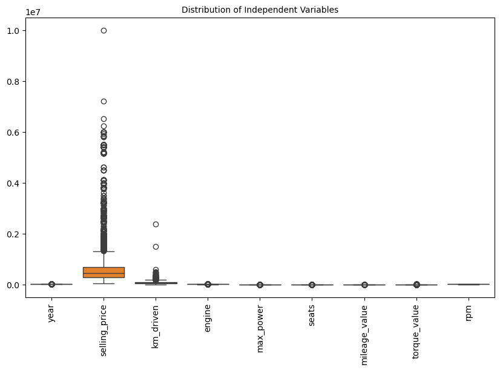

```python
# Checking for outliers
plt.figure(figsize=(10, 6))
sns.boxplot(data=cars_data)
plt.title('Distribution of Independent Variables', fontsize = 10)
# xticks() returns the x-axis ticks
# 'rotation = vertical' rotates the x-axis labels vertically
plt.xticks(rotation = 'vertical', fontsize = 10)
plt.show()
```

### Interpretation: From the above plots, we notice that the variables 'selling price' and 'km_driven' have points above the upper extreme or below the lower extreme - these points are outliers in the data. However, the exact location of these points is not precisely seen.

### Let us use the IQR method to remove the outliers.

```python
# Outlier treatment
q1 = cars_data['selling_price'].quantile(0.25)
q3 = cars_data['selling_price'].quantile(0.75)
iqr = q3 - q1
upper_bound = q3 + 1.5 * iqr
lower_bound = q1-1.5 * iqr
cars_data = cars_data[(cars_data['selling_price'] <= upper_bound) & (cars_data['selling_price'] >= lower_bound) ]
```

```python
q1 = cars_data['km_driven'].quantile(0.25)
q3 = cars_data['km_driven'].quantile(0.75)
iqr = q3 - q1
upper_bound = q3 + 1.5 * iqr
lower_bound = q1-1.5 * iqr
cars_data = cars_data[(cars_data['km_driven'] <= upper_bound) & (cars_data['km_driven'] >= lower_bound) ]
```

```python
# check the shape of the data
cars_data.shape
```

```
(7016, 18)
```

### Interpretation: A crude way to know whether the outliers have been removed or not is to check the dimensions of the data. From the above output, we can see that the dimensions are reduced that implies outliers are removed.

```python
 # Descriptive statistics for numerical variables
numerical_stats = cars_data.describe()
print("Descriptive statistics for numerical variables:")
numerical_stats
```

```
Descriptive statistics for numerical variables:
```

|  | year | selling_price | km_driven | engine | max_power | seats | mileage_value | torque_value | rpm |
| --- | --- | --- | --- | --- | --- | --- | --- | --- | --- |
| count | 7016.000000 | 7.016000e+03 | 7016.000000 | 7016.000000 | 7016.000000 | 7016.000000 | 7016.000000 | 7016.000000 | 7016.000000 |
| mean | 2013.788626 | 4.522523e+05 | 66785.337514 | 1373.204532 | 83.778987 | 5.369869 | 19.918799 | 163.272549 | 2904.296893 |
| std | 3.832999 | 2.442088e+05 | 38526.808164 | 438.401336 | 24.868782 | 0.921525 | 4.142949 | 103.332630 | 954.103957 |
| min | 1994.000000 | 2.999900e+04 | 1.000000 | 624.000000 | 32.800000 | 2.000000 | 0.000000 | 14.900000 | 252.000000 |
| 25% | 2012.000000 | 2.500000e+05 | 35000.000000 | 1196.000000 | 67.100000 | 5.000000 | 17.200000 | 110.000000 | 2000.000000 |
| 50% | 2014.000000 | 4.250000e+05 | 60000.000000 | 1248.000000 | 81.800000 | 5.000000 | 19.700000 | 146.119085 | 2400.000000 |
| 75% | 2017.000000 | 6.250000e+05 | 93000.000000 | 1497.000000 | 94.930000 | 5.000000 | 22.740000 | 200.000000 | 4000.000000 |
| max | 2020.000000 | 1.180000e+06 | 180000.000000 | 3498.000000 | 272.000000 | 14.000000 | 46.816000 | 3726.527000 | 5000.000000 |

### Insight:

[output not shown]

```python
# Descriptive statistics for categorical variables
categorical_cols = ['name','Region', 'State or Province', 'City', 'fuel', 'seller_type', 'transmission', 'owner', 'sold']
categorical_stats = {}
for col in categorical_cols:
    categorical_stats[col] = cars_data[col].value_counts()

print("\nDescriptive statistics for categorical variables:")
for col, stats in categorical_stats.items():
    print(f"\n{col}:")
    print(stats)
```

```
Descriptive statistics for categorical variables:

name:
Maruti Swift Dzire VDI                          129
Maruti Alto 800 LXI                              82
Maruti Alto LXi                                  71
Maruti Swift VDI                                 59
Maruti Wagon R LXI                               52
                                               ...
Hyundai Verna CRDi 1.6 AT SX Option               1
Chevrolet Sail Hatchback Petrol                   1
Fiat Punto Pure 1.2L FIRE                         1
Mahindra Scorpio 2009-2014 EX 9S BSIII            1
Toyota Innova 2.5 GX (Diesel) 8 Seater BS IV      1
Name: name, Length: 1771, dtype: int64

Region:
Central    2130
West       1764
East       1722
South      1400
Name: Region, dtype: int64

State or Province:
California              826
Illinois                455
New York                439
Texas                   429
Florida                 371
Ohio                    283
Michigan                266
Washington              261
Pennsylvania            212
Indiana                 189
North Carolina          182
Massachusetts           165
Georgia                 159
Minnesota               156
Virginia                151
New Jersey              138
```

[output cut: 63 more lines]

```
Manual       6484
Automatic     532
Name: transmission, dtype: int64

owner:
First Owner             4521
Second Owner            1866
Third Owner              482
Fourth & Above Owner     147
Name: owner, dtype: int64

sold:
N    5248
Y    1768
Name: sold, dtype: int64
```

### Inference :

[output not shown]

## Which brands are selling most?

```python
# Count the occurrences of each brand
brand_counts = cars_data['name'].value_counts()

# Display the top 10 selling brands
print("Top 10 selling brands:")
brand_counts.head(10)
```

```
Top 10 selling brands:
```

```
Maruti Swift Dzire VDI      129
Maruti Alto 800 LXI          82
Maruti Alto LXi              71
Maruti Swift VDI             59
Maruti Wagon R LXI           52
Maruti Alto K10 VXI          50
Hyundai EON Era Plus         48
Maruti Wagon R VXI BS IV     44
Maruti Ertiga VDI            43
Maruti Alto LX               43
Name: name, dtype: int64
```

## Are there specific locations selling more?

```python
state_province_stats = cars_data['State or Province'].value_counts()

print("\nDescriptive statistics for State or Province:")
state_province_stats.head(10)
```

```
Descriptive statistics for State or Province:
```

```
California      826
Illinois        455
New York        439
Texas           429
Florida         371
Ohio            283
Michigan        266
Washington      261
Pennsylvania    212
Indiana         189
Name: State or Province, dtype: int64
```

```python
# Descriptive statistics for City
city_stats = cars_data['City'].value_counts()

print("\nDescriptive statistics for City:")
city_stats.head(10)
```

```
Descriptive statistics for City:
```

```
New York City    177
Los Angeles      172
Seattle           80
Chicago           79
Boston            65
Washington        64
Philadelphia      51
Charlotte         39
Miami             37
Atlanta           36
Name: City, dtype: int64
```

### Inference:

```
 State or Province:
    California has the highest number of listings with 826 cars.
    Following California, other states such as Texas, New York, and Illinois also have a significant number of listings.
    These states likely have high demand for used cars or are areas with a large population,leading to more transactions.


 City:
    New York City and Los Angeles have the highest number of listings with 177 and 172 cars respectively.
    Other cities like Seattle, Chicago, and Boston also have a considerable number of listings.
    These cities may have higher demand for used cars due to their large populations, urban lifestyle, or transportation needs.
```

## Which variables are significant in predicting the price of a used car?

```python
# Compute the correlation matrix
correlation_matrix = cars_data.corr()

# Print correlation with the target variable (selling_price)
print(correlation_matrix['selling_price'].sort_values(ascending=False))
```

```
selling_price    1.000000
year             0.651663
max_power        0.536074
engine           0.369832
torque_value     0.313076
seats            0.241343
mileage_value    0.069221
rpm             -0.152582
km_driven       -0.265438
Name: selling_price, dtype: float64
```

### Inference:

```
     Year (year): There is a moderately positive correlation (0.65) between the year of manufacture and the selling price. This suggests that newer cars tend to have higher selling prices, which is a common expectation due to factors like depreciation and technological advancements.

Maximum Power (max_power): There is a moderate positive correlation (0.54) between the maximum power of the car and its selling price. Cars with higher maximum power ratings may command higher prices due to perceived performance benefits.

Engine Capacity (engine): There is a moderate positive correlation (0.37) between the engine capacity and the selling price. Generally, cars with larger engine capacities tend to have higher selling prices, as they may offer more power and performance.

Torque Value (torque_value): There is a weak positive correlation (0.31) between the torque value and the selling price. Torque is an important factor in determining the performance and drivability of a car, so higher torque values may contribute to higher selling prices to some extent.

Number of Seats (seats): There is a weak positive correlation (0.24) between the number of seats and the selling price. Cars with more seats may appeal to families or individuals needing more passenger capacity, potentially leading to higher selling prices.

Mileage Value (mileage_value): There is a very weak positive correlation (0.07) between the mileage value and the selling price. This correlation suggests that there might be a slight tendency for cars with higher mileage values to have higher selling prices, but the effect is minimal.

RPM (rpm): There is a weak negative correlation (-0.15) between the RPM (revolutions per minute) and the selling price. This might imply that cars with lower RPM values (possibly indicating higher gear ratios or fuel efficiency) could have higher selling prices.

Kilometers Driven (km_driven): There is a moderately negative correlation (-0.26) between the kilometers driven and the selling price. This suggests that cars with lower mileage tend to have higher selling prices, which is expected as lower mileage often correlates with newer or less used vehicles.
```

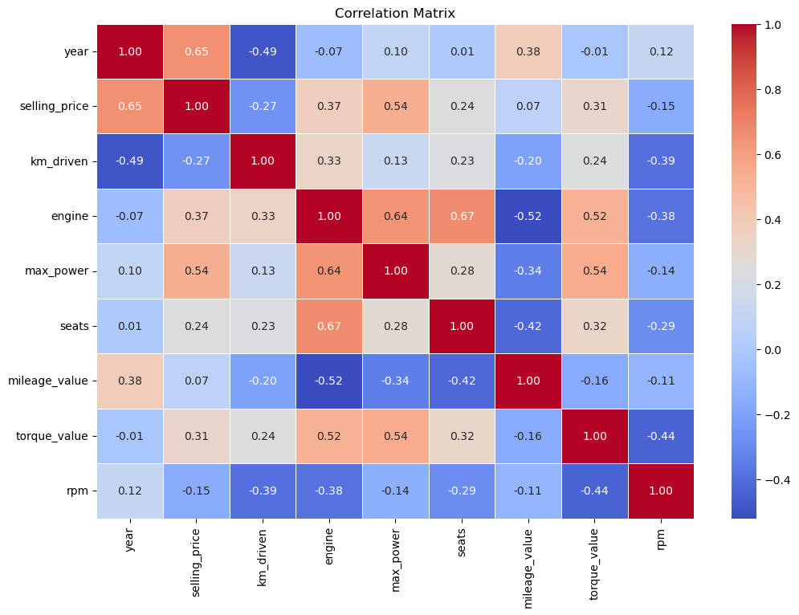

```python
# Plot the correlation matrix as a heatmap
plt.figure(figsize=(12, 8))
sns.heatmap(correlation_matrix, annot=True, cmap='coolwarm', fmt=".2f", linewidths=0.5)
plt.title('Correlation Matrix')
plt.show()
```

```python
cars_data.columns
```

```
Index(['name', 'year', 'selling_price', 'km_driven', 'Region',
       'State or Province', 'City', 'fuel', 'seller_type', 'transmission',
       'owner', 'engine', 'max_power', 'seats', 'sold', 'mileage_value',
       'torque_value', 'rpm'],
      dtype='object')
```

```python
num_cols=['year', 'selling_price', 'km_driven','engine','max_power', 'seats','mileage_value',
       'torque_value', 'rpm']
```

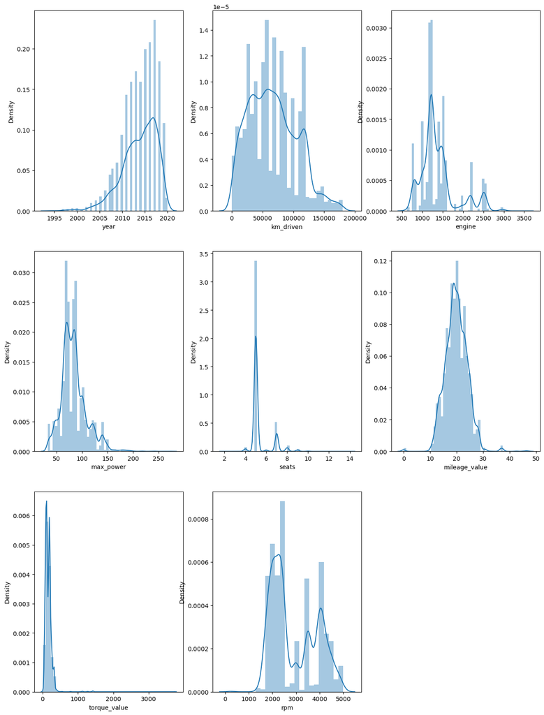

```python
# Distplot for Numerical variables
plt.figure(figsize=(15,85))
plot_num=1
for i in num_cols:
    ax=plt.subplot(12,3,plot_num)
    sns.distplot(cars_data[i])
    plot_num+=1
plt.show()
```

```python
cat_cols=['name','Region','State or Province', 'City', 'fuel', 'seller_type', 'transmission',
       'owner', 'sold']
```

```python
# Checking no: of sub-categories for each categorical columns
for i in cat_cols:
    print(i,":",cars_data[i].nunique())
```

```
name : 1771
Region : 4
State or Province : 49
City : 1285
fuel : 4
seller_type : 3
transmission : 2
owner : 4
sold : 2
```

```python
# dropping name,and city column as it is not required for the analyiss
```

```python
cars_data.drop(columns=['name','City'],axis=1,inplace=True)
```

```python
cars_data.columns
```

```
Index(['year', 'selling_price', 'km_driven', 'Region', 'State or Province',
       'fuel', 'seller_type', 'transmission', 'owner', 'engine', 'max_power',
       'seats', 'sold', 'mileage_value', 'torque_value', 'rpm'],
      dtype='object')
```

```python
cat_cols1=['Region','State or Province','fuel', 'seller_type', 'transmission',
       'owner', 'sold']
```

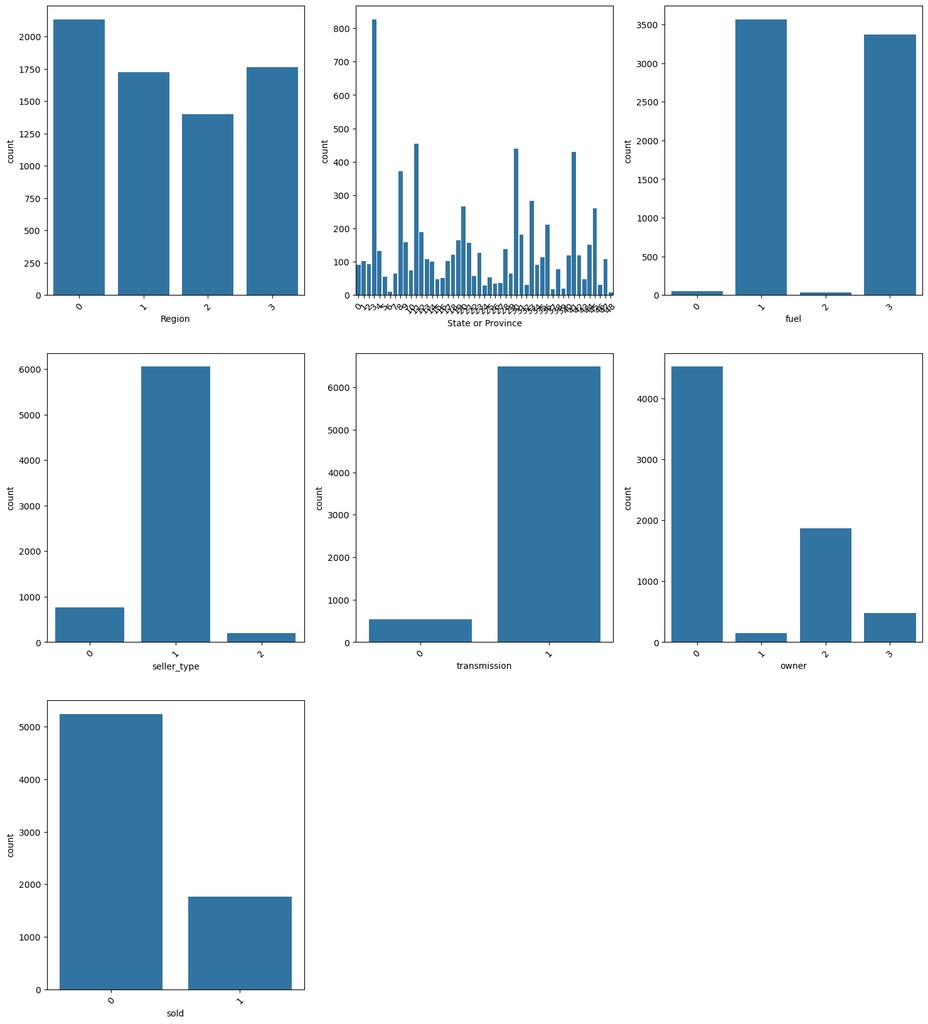

```python
# Countplot for categorical variables

plt.figure(figsize=(18,85))
plot_num=1
for i in cat_cols1:
    ax=plt.subplot(12,3,plot_num)
    sns.countplot(x=i,data=cars_data)
    plt.xticks(rotation=45)
    plot_num+=1
plt.show()
```

### Observations:

```
Central region has the high count .
California has the highest count in used cars.
fuel type Diesel is slightly high comapred to petrol.
Individual seller is in demand compared to dealers.
Manual transmission type is in much demand.
Fisrt owner is preferred more and than comes second owner.
Sold count is less need to do further analysis to improve the count.
```

## How well those variables describe the price of a car?

```python
num_cols1=['year','km_driven','engine','max_power', 'seats','mileage_value',
       'torque_value', 'rpm']
```

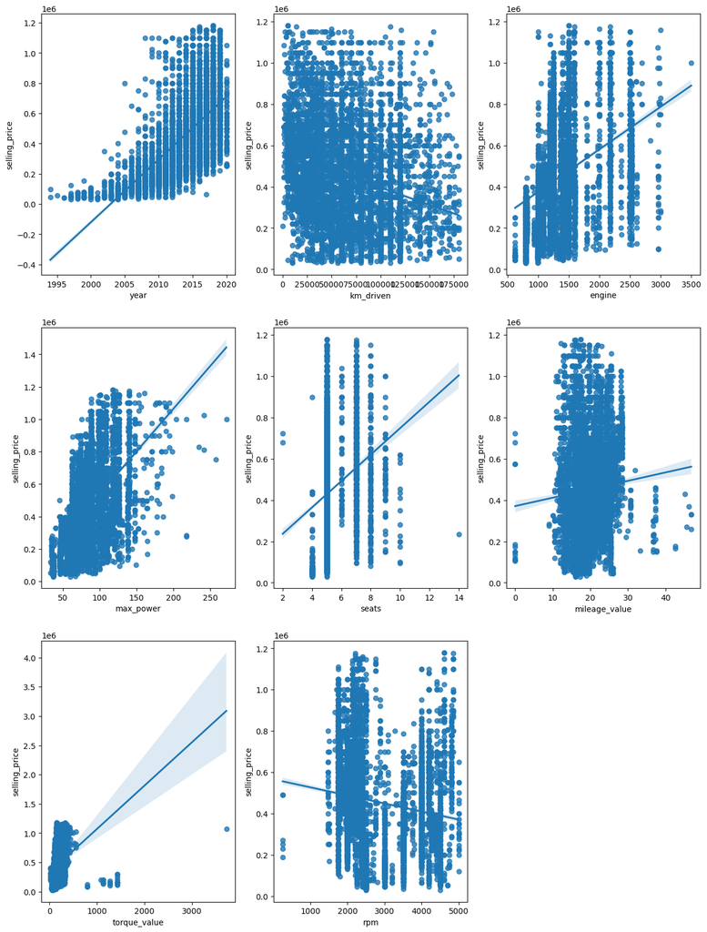

```python
# Plotting the relationship between year and selling price

plt.figure(figsize=(15,85))
plot_num=1
for i in num_cols1:
    ax=plt.subplot(12,3,plot_num)
    sns.regplot(y='selling_price',x=cars_data[i],data=cars_data)
    plt.xlabel(i)
    plot_num+=1
plt.show()
```

### Inference :

Kilometers Driven vs. Selling Price: There’s a negative correlation between the kilometers driven and the selling price. Cars with higher mileage tend to be priced lower.

Engine Size vs. Selling Price: Larger engine sizes are associated with higher selling prices. More powerful engines often come with a premium.

Maximum Power vs. Selling Price: Cars with higher maximum power (horsepower) tend to have higher selling prices. Performance matters!

Seats vs. Selling Price: The number of seats doesn’t show a strong correlation with selling price. Other factors play a bigger role.

Torque vs. Selling Price: Cars with higher torque tend to have higher selling prices.

RPM vs. Selling Pric: cars with lower RPM have higher selling price.

## Perform relevant hypothesis testing

H0: Population mean of selling price is same for all fuel types.

H1: Any one population mean is different from others. (Relationship exists)

alpha=0.05

```python
from scipy.stats import f_oneway

# Perform ANOVA for fuel type
fuel_types = cars_data['fuel'].unique()
fuel_groups = [cars_data[cars_data['fuel'] == fuel]['selling_price'] for fuel in fuel_types]
anova_results = f_oneway(*fuel_groups)
print("ANOVA Results for Fuel Type:")
print("F-statistic:", anova_results.statistic)
print("p-value:", anova_results.pvalue)
```

```
ANOVA Results for Fuel Type:
F-statistic: 256.63653113579056
p-value: 4.97420488216794e-158
```

### Inference :

P-value is less than alpha.so we Reject Ho. we can conclude that selling price is impacted by fuel type.

### Hypothesis test :

H0: Population mean of selling price is same for all owner types.

H1: Any one population mean is different from others. (Relationship exists)

alpha=0.05

```python
from scipy.stats import f_oneway
owner_types = cars_data['owner'].unique()
owner_groups = [cars_data[cars_data['owner'] == o]['selling_price'] for o in owner_types]
anova_results = f_oneway(*owner_groups)
print("ANOVA Results for Owner Type:")
print("F-statistic:", anova_results.statistic)
print("p-value:", anova_results.pvalue)
```

```
ANOVA Results for Owner Type:
F-statistic: 375.66531855804453
p-value: 2.859934021831088e-226
```

### Inference :

P-value is less than alpha.so we Reject Ho. we can conclude that selling price is impacted by owner type.

### Hypothesis test :

H0: Population mean of selling price is same for all seller types.

H1: Any one population mean is different from others. (Relationship exists)

alpha=0.05

```python
from scipy.stats import f_oneway
owner_types = cars_data['seller_type'].unique()
owner_groups = [cars_data[cars_data['seller_type'] == o]['selling_price'] for o in owner_types]
anova_results = f_oneway(*owner_groups)
print("ANOVA Results for Seller Type:")
print("F-statistic:", anova_results.statistic)
print("p-value:", anova_results.pvalue)
```

```
ANOVA Results for Seller Type:
F-statistic: 179.60387141147604
p-value: 8.530022562064251e-77
```

### Inference :

P-value is less than alpha.so we Reject Ho. we can conclude that selling price is impacted by seller type.

### Hypothesis test:

H0: Population mean of selling price is same for all transmission types.

H1: Any one population mean is different from others. (Relationship exists)

alpha=0.05

```python
from scipy.stats import ttest_ind

#Perform independent samples t-test for transmission
Manual_prices = cars_data[cars_data['transmission'] == 'Manual']['selling_price']
Automatic_prices = cars_data[cars_data['transmission'] == 'Automatic']['selling_price']

t_statistic, p_value = ttest_ind(Manual_prices, Automatic_prices)
print("\nIndependent Samples t-test Results for Transmission Type:")
print(f"t-statistic: {t_statistic}")
print(f"p-value: {p_value}")
```

```
Independent Samples t-test Results for Transmission Type:
t-statistic: -20.27631624537384
p-value: 7.067099649185384e-89
```

### Inference :

```
P-value is less than alpha.so we Reject Ho.
we can conclude that selling price is impacted by transmission type.
```

### The small p-values indicate strong evidence against the null hypothesis, suggesting that these categorical variables have a significant impact on the selling price.

#### converting categorical to numerical

```python
cars_data.dtypes
```

```
year                   int64
selling_price          int64
km_driven              int64
Region                object
State or Province     object
fuel                  object
seller_type           object
transmission          object
owner                 object
engine                 int32
max_power            float64
seats                  int64
sold                  object
mileage_value        float64
torque_value         float64
rpm                  float64
dtype: object
```

```python
from sklearn.preprocessing import LabelEncoder
```

```python
label_encoder=LabelEncoder()
```

```python
cars_data['Region']=label_encoder.fit_transform(cars_data['Region'])
cars_data['State or Province']=label_encoder.fit_transform(cars_data['State or Province'])
cars_data['fuel']=label_encoder.fit_transform(cars_data['fuel'])
cars_data['seller_type']=label_encoder.fit_transform(cars_data['seller_type'])
cars_data['transmission']=label_encoder.fit_transform(cars_data['transmission'])
cars_data['owner']=label_encoder.fit_transform(cars_data['owner'])
cars_data['sold']=label_encoder.fit_transform(cars_data['sold'])
```

```python
cars_data.shape
```

```
(7016, 16)
```

```python
data=cars_data.copy()
```

```python
data.info()
```

```
<class 'pandas.core.frame.DataFrame'>
Int64Index: 7016 entries, 0 to 7905
Data columns (total 16 columns):
 #   Column             Non-Null Count  Dtype
---  ------             --------------  -----
 0   year               7016 non-null   int64
 1   selling_price      7016 non-null   int64
 2   km_driven          7016 non-null   int64
 3   Region             7016 non-null   int32
 4   State or Province  7016 non-null   int32
 5   fuel               7016 non-null   int32
 6   seller_type        7016 non-null   int32
 7   transmission       7016 non-null   int32
 8   owner              7016 non-null   int32
 9   engine             7016 non-null   int32
 10  max_power          7016 non-null   float64
 11  seats              7016 non-null   int64
 12  sold               7016 non-null   int32
 13  mileage_value      7016 non-null   float64
 14  torque_value       7016 non-null   float64
 15  rpm                7016 non-null   float64
dtypes: float64(4), int32(8), int64(4)
memory usage: 712.6 KB
```

```python
X= data.drop("selling_price", axis=1)
y=data['selling_price']
```

```python
#Scaling

sc= StandardScaler()

for i in X.columns:
    X[i]= sc.fit_transform(X[i].values.reshape(-1,1))
```

```python
X.head()
```

|  | year | km_driven | Region | State or Province | fuel | seller_type | transmission | owner | engine | max_power | seats | sold | mileage_value | torque_value | rpm |
| --- | --- | --- | --- | --- | --- | --- | --- | --- | --- | --- | --- | --- | --- | --- | --- |
| 0 | 0.055150 | 2.043260 | -0.343261 | -1.023930 | -0.951030 | 0.220025 | 0.28644 | -0.714919 | -0.285614 | -0.393251 | -0.401395 | 1.722883 | 0.840331 | 0.258673 | -0.947865 |
| 1 | 0.055150 | 1.381336 | -0.343261 | 0.566192 | -0.951030 | 0.220025 | 0.28644 | 1.168977 | 0.284681 | 0.793864 | -0.401395 | 1.722883 | 0.294787 | 0.839363 | -0.947865 |
| 2 | -2.032138 | 1.900492 | -1.203990 | -0.747387 | 1.033925 | 0.220025 | 0.28644 | 2.110925 | 0.282399 | -0.232396 | -0.401395 | 1.722883 | -0.535599 | -0.374817 | -0.528593 |
| 3 | -0.988494 | 1.563040 | -1.203990 | -0.747387 | -0.951030 | 0.220025 | 0.28644 | -0.714919 | 0.052001 | 0.250171 | -0.401395 | 1.722883 | 0.743775 | 0.545814 | -0.528593 |
| 4 | -1.771227 | 1.381336 | -0.343261 | 0.566192 | 1.033925 | 0.220025 | 0.28644 | -0.714919 | -0.171555 | 0.177786 | -0.401395 | 1.722883 | -0.921824 | -0.488710 | -0.528593 |

#### DATA IS CLEANED NOW IT IS READY FOR MODEL BUILDING

## MODEL BUILDING:

### Assumptions Before LR Model:

There are several assumptions of linear regression. We can check two of them before building the regression model. Let us check the following assumptions in this section:

1. Assumption on Dependent Variable
2. No or little multicollinearity

Let us create the dataframes for independent and target variable to check the assumptions of linear regression.

```python
# create dataframe of features by dropping the target variable
# 'axis = 1' drops the corresponding column(s)
X= data.drop("selling_price", axis=1)

# create dataframe of target variable
y=data['selling_price']
```

```python
# check the data type of dependent variable
y.dtype
```

```
dtype('int64')
```

No or Little Multicollinearity Whenever there are a large number of independent variables present in the dataset, there is a possibility that such independent variables will be strongly correlated. The presence of a strong correlation between the independent variables is called multicollinearity.

The presence of multicollinearity can destabilize the model. Thus, the existence of multicollinearity must be detected and corrected actions should be taken.

If we use dummy variables to encode a categorical variable and do not omit the parent column, then this results in a strong correlation between the dummy variables and the parent column.

#### Correlation Matrix

Let us plot the heatmap to visualize the correlation matrix of the independent variables. The variables with a high correlation may induce multicollinearity in the data.

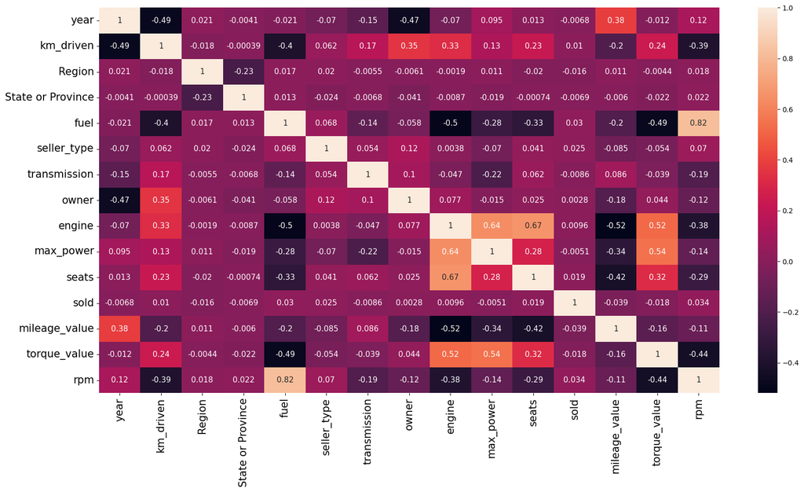

```python
# set the plot size using figure()
# pass width and height in inches to 'figsize'
plt.figure(figsize = (20,10))

# plot the heat map
# corr(): give the correlation matrix
# annot: prints the correlation values in the chart
# annot_kws: used to set the font size of the annotation
sns.heatmap(X.corr(), annot = True, annot_kws = {"size": 11})

# rotation = 'horizontal' rotates the y-axis labels horizontally
# set text size using 'fontsize'
plt.yticks(rotation = 'horizontal', fontsize = 15)
plt.xticks(fontsize = 15)

# display the plot
plt.show()
```

Identify the variables with a correlation greater than 0.8 and less than -0.8

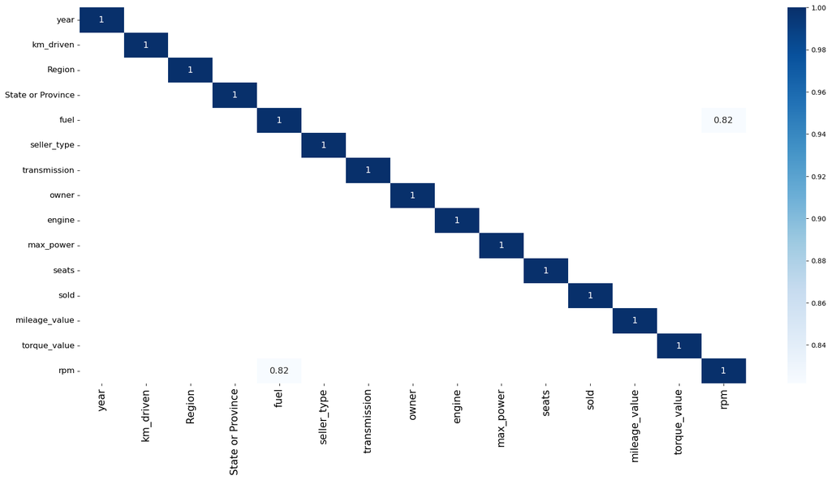

```python
# set the plot size using figure()
# pass width and height in inches to 'figsize'
plt.figure(figsize = (22,10))

# plot the heat map
# corr(): give the correlation matrix
# annot: prints the correlation values in the chart
# annot_kws: sets the font size of the annotation
sns.heatmap(X.corr()[np.abs(X.corr()) > 0.8], annot = True, annot_kws = {"size": 13}, cmap = 'Blues')

# rotate the y-axis labels
# set text size using 'fontsize'
plt.yticks(rotation = 'horizontal', fontsize = 12)
plt.xticks(fontsize = 15)

# display the plot
plt.show()
```

### Build the LR Model

```python
from sklearn.model_selection import train_test_split
```

```python
xtrain,xtest,ytrain,ytest=train_test_split(X,y,test_size=0.2,random_state=10)
```

```python
print(f'xtrain shape:{xtrain.shape}')
print(f'xtest shape:{xtest.shape}')
print(f'ytrain shape:{ytrain.shape}')
print(f'ytest shape:{ytest.shape}')
```

```
xtrain shape:(5612, 15)
xtest shape:(1404, 15)
ytrain shape:(5612,)
ytest shape:(1404,)
```

```python
from sklearn.linear_model import LinearRegression
```

```python
lr=LinearRegression()
```

```python
lr.fit(xtrain,ytrain)
```

```
LinearRegression()
```

```python
ypred = lr.predict(xtest)
```

```python
from sklearn.metrics import mean_squared_error,mean_absolute_error,mean_absolute_percentage_error,r2_score,confusion_matrix,ConfusionMatrixDisplay
```

```python
mse = mean_squared_error(ytest,ypred)
Rmse = np.sqrt(mean_squared_error(ytest,ypred))
mae = mean_absolute_error(ytest,ypred)
mape= mean_absolute_percentage_error(ytest,ypred)
r2 =r2_score(ytest,ypred)
```

```python
print('MSE:', mse)
print('RMSE:', Rmse)
print('MAE:', mae)
print('MAPE:', mape)
print('R2 Score:', r2)
```

```
MSE: 17159301338.43161
RMSE: 130993.51639845237
MAE: 102192.43470490575
MAPE: 0.3526433431901075
R2 Score: 0.6993910174556006
```

```python
#training accuracy
y_pred_train = linear_reg_model.predict(xtrain)
r2_score(ytrain,y_pred_train)
```

```
0.7120712219181247
```

```python
# k-Fold Cross Validation
cv_score = cross_val_score(estimator = lr, X = xtrain, y = ytrain, cv = 5)
print("Cross Validation Score is: {}".format(cv_score.mean()))
```

```
Cross Validation Score is: 0.7095835632235549
```

### Result:

```
While the test R2 score is reasonably close to the training R2 score, the slight drop suggests that the model may not generalize well to new, unseen data as it does to the training data.
```

### Feature Importance after LR Model:

```python
features = X.columns
```

```python
importance_lr = linear_reg_model.coef_
```

```python
# Assuming 'features' is a list of feature names
feature_imp1 = pd.DataFrame({"Variable": features, "Coefficient": importance_lr}).round(decimals=2).sort_values("Coefficient", ascending=False)
feature_imp1.style.bar(color=['red', 'green'])
```

|  | Variable | Coefficient |
| --- | --- | --- |
| 0 | year | 33531.040000 |
| 10 | seats | 8985.400000 |
| 9 | max_power | 3633.420000 |
| 8 | engine | 64.590000 |
| 1 | km_driven | -0.950000 |
| 14 | rpm | -35.370000 |
| 13 | torque_value | -38.610000 |
| 3 | State or Province | -81.710000 |
| 12 | mileage_value | -251.480000 |
| 2 | Region | -694.270000 |
| 11 | sold | -3892.080000 |
| 5 | seller_type | -8428.790000 |
| 7 | owner | -14850.130000 |
| 4 | fuel | -17440.470000 |
| 6 | transmission | -71174.090000 |

From these coefficients, it appears that the most influential variables in determining the selling price are:

```
Year of manufacture
Transmission type
Fuel type
Number of owners
Number of seats
```

### OLS Regression:

```python
xtrain = sm.add_constant(xtrain)

# Fit an OLS model using statsmodels
results = sm.OLS(ytrain, xtrain).fit()

# Print the summary results
print(results.summary())
```

```
                            OLS Regression Results
==============================================================================
Dep. Variable:          selling_price   R-squared:                       0.712
Model:                            OLS   Adj. R-squared:                  0.711
Method:                 Least Squares   F-statistic:                     922.6
Date:                Wed, 20 Mar 2024   Prob (F-statistic):               0.00
Time:                        15:15:18   Log-Likelihood:                -74120.
No. Observations:                5612   AIC:                         1.483e+05
Df Residuals:                    5596   BIC:                         1.484e+05
Df Model:                          15
Covariance Type:            nonrobust
=====================================================================================
                        coef    std err          t      P>|t|      [0.025      0.975]
-------------------------------------------------------------------------------------
const             -6.721e+07   1.32e+06    -50.779      0.000   -6.98e+07   -6.46e+07
year               3.353e+04    662.083     50.645      0.000    3.22e+04    3.48e+04
km_driven            -0.9505      0.061    -15.658      0.000      -1.069      -0.831
Region             -694.2669   1564.507     -0.444      0.657   -3761.308    2372.774
State or Province   -81.7124    125.297     -0.652      0.514    -327.343     163.918
fuel              -1.744e+04   4081.552     -4.273      0.000   -2.54e+04   -9439.045
seller_type       -8428.7857   4954.288     -1.701      0.089   -1.81e+04    1283.542
transmission      -7.117e+04   7128.245     -9.985      0.000   -8.51e+04   -5.72e+04
owner             -1.485e+04   1913.281     -7.762      0.000   -1.86e+04   -1.11e+04
engine               64.5896      8.720      7.407      0.000      47.495      81.684
max_power          3633.4213    108.573     33.465      0.000    3420.576    3846.267
seats              8985.4012   2804.661      3.204      0.001    3487.178    1.45e+04
sold              -3892.0811   4068.735     -0.957      0.339   -1.19e+04    4084.217
mileage_value      -251.4839    748.759     -0.336      0.737   -1719.342    1216.374
torque_value        -38.6104     22.547     -1.712      0.087     -82.812       5.591
rpm                 -35.3688      3.467    -10.200      0.000     -42.166     -28.571
==============================================================================
Omnibus:                      219.827   Durbin-Watson:                   2.029
Prob(Omnibus):                  0.000   Jarque-Bera (JB):              281.247
Skew:                           0.423   Prob(JB):                     8.47e-62
Kurtosis:                       3.699   Cond. No.                     5.82e+07
==============================================================================

Notes:
[1] Standard Errors assume that the covariance matrix of the errors is correctly specified.
[2] The condition number is large, 5.82e+07. This might indicate that there are
strong multicollinearity or other numerical problems.
```

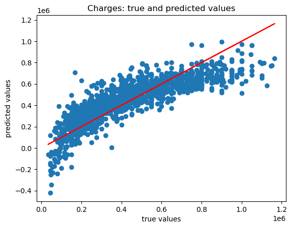

```python
# Add a constant to the model because it's best practice
# to do so every time!
xtest = sm.add_constant(xtest)

# You are making predictions here
ols_y_preds = results.predict(xtest)

plt.scatter(ytest, ols_y_preds)
plt.plot(ytest, ytest, color="red")
plt.xlabel("true values")
plt.ylabel("predicted values")
plt.title("Charges: true and predicted values")
plt.show()
```

### Result :

[output not shown]

## Decision Tree Regressor

```python
from sklearn.tree import DecisionTreeRegressor
```

```python
dreg=DecisionTreeRegressor()
```

```python
dreg.fit(xtrain,ytrain)
```

```
DecisionTreeRegressor()
```

```python
ypred=dreg.predict(xtest)
```

```python
from sklearn.metrics import mean_squared_error,mean_absolute_error,mean_absolute_percentage_error,r2_score,confusion_matrix,ConfusionMatrixDisplay
```

```python
mse = mean_squared_error(ytest,ypred)
Rmse = np.sqrt(mean_squared_error(ytest,ypred))
mae = mean_absolute_error(ytest,ypred)
mape= mean_absolute_percentage_error(ytest,ypred)
r2 =r2_score(ytest,ypred)
```

```python
print('MSE:', mse)
print('RMSE:', Rmse)
print('MAE:', mae)
print('MAPE:', mape)
print('R2 Score:', r2)
```

```
MSE: 10360827478.987358
RMSE: 101788.14999295035
MAE: 69124.08368945868
MAPE: 0.1919416396187429
R2 Score: 0.8184915722762685
```

```python
#training accuracy
y_pred_train = dreg.predict(xtrain)
r2_score(ytrain,y_pred_train)
```

```
0.9996064888790831
```

### The metrics indicate that your model performs reasonably well.The extremely high training accuracy may raise concerns about overfitting.

### HyperParameter Tuning using GRIDSEARCHCV

```python
from sklearn import tree
```

```python
from sklearn.model_selection import GridSearchCV
```

```python
mod = GridSearchCV(DecisionTreeRegressor(),param_grid={'max_depth':[i for i in range(5,10)],
                                                       'min_samples_leaf':[i for i in range(10,100,5)],
                                    'max_leaf_nodes':[i for i in range(5,50,5)]})
```

```python
mod.fit(xtrain,ytrain)
```

```
GridSearchCV(estimator=DecisionTreeRegressor(),
             param_grid={'max_depth': [5, 6, 7, 8, 9],
                         'max_leaf_nodes': [5, 10, 15, 20, 25, 30, 35, 40, 45],
                         'min_samples_leaf': [10, 15, 20, 25, 30, 35, 40, 45,
                                              50, 55, 60, 65, 70, 75, 80, 85,
                                              90, 95]})
```

```python
mod.best_estimator_
```

```
DecisionTreeRegressor(max_depth=8, max_leaf_nodes=45, min_samples_leaf=15)
```

```python
mod.best_score_
```

```
0.8266860755573736
```

```python
mod.best_params_
```

```
{'max_depth': 8, 'max_leaf_nodes': 45, 'min_samples_leaf': 15}
```

```python
dreg3=DecisionTreeRegressor(max_depth=8, max_leaf_nodes=45, min_samples_leaf=15)
dreg3.fit(xtrain,ytrain)
```

```
DecisionTreeRegressor(max_depth=8, max_leaf_nodes=45, min_samples_leaf=15)
```

```python
ypredgrid=dreg3.predict(xtest)
```

```python
r2_score(ytest,ypredgrid)
```

```
0.8141416788149656
```

```python
y_pred_train_grid = dreg3.predict(xtrain)
r2_score(ytrain,y_pred_train_grid)
```

```
0.8438163526716883
```

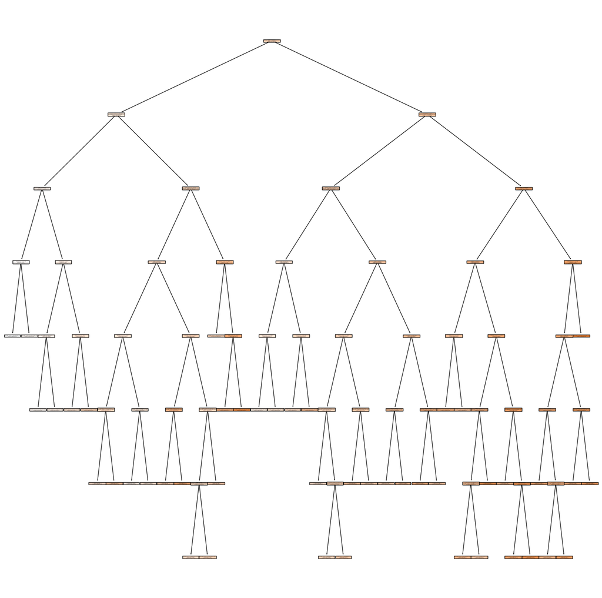

```python
from sklearn import tree
plt.figure(figsize=(20,20))
tree.plot_tree(dreg3,feature_names=list(xtrain.columns.values),class_names=['0','1'],filled=True);
```

```python
#tree rules
treerules = tree.export_text(dreg3,feature_names=list(xtrain.columns.values))
print(treerules)
```

```
|--- year <= 2013.50
|   |--- torque_value <= 166.40
|   |   |--- year <= 2009.50
|   |   |   |--- max_power <= 62.05
|   |   |   |   |--- value: [88597.77]
|   |   |   |--- max_power >  62.05
|   |   |   |   |--- value: [148171.22]
|   |   |--- year >  2009.50
|   |   |   |--- max_power <= 79.70
|   |   |   |   |--- engine <= 996.50
|   |   |   |   |   |--- value: [163221.58]
|   |   |   |   |--- engine >  996.50
|   |   |   |   |   |--- value: [223416.10]
|   |   |   |--- max_power >  79.70
|   |   |   |   |--- max_power <= 110.20
|   |   |   |   |   |--- value: [311473.01]
|   |   |   |   |--- max_power >  110.20
|   |   |   |   |   |--- value: [435257.09]
|   |--- torque_value >  166.40
|   |   |--- max_power <= 139.05
|   |   |   |--- year <= 2011.50
|   |   |   |   |--- mileage_value <= 12.85
|   |   |   |   |   |--- mileage_value <= 12.75
|   |   |   |   |   |   |--- value: [345960.73]
|   |   |   |   |   |--- mileage_value >  12.75
|   |   |   |   |   |   |--- value: [559230.73]
|   |   |   |   |--- mileage_value >  12.85
|   |   |   |   |   |--- year <= 2009.50
|   |   |   |   |   |   |--- value: [226279.98]
|   |   |   |   |   |--- year >  2009.50
|   |   |   |   |   |   |--- value: [307647.29]
|   |   |   |--- year >  2011.50
|   |   |   |   |--- mileage_value <= 13.24
|   |   |   |   |   |--- mileage_value <= 12.50
|   |   |   |   |   |   |--- value: [493380.90]
|   |   |   |   |   |--- mileage_value >  12.50
|   |   |   |   |   |   |--- value: [758826.07]
|   |   |   |   |--- mileage_value >  13.24
|   |   |   |   |   |--- max_power <= 106.72
|   |   |   |   |   |   |--- seats <= 6.00
```

[output cut: 78 more lines]

```
|   |   |   |   |--- year <= 2017.50
|   |   |   |   |   |--- rpm <= 2162.50
|   |   |   |   |   |   |--- value: [773353.41]
|   |   |   |   |   |--- rpm >  2162.50
|   |   |   |   |   |   |--- max_power <= 113.40
|   |   |   |   |   |   |   |--- value: [658539.97]
|   |   |   |   |   |   |--- max_power >  113.40
|   |   |   |   |   |   |   |--- value: [836666.60]
|   |   |   |   |--- year >  2017.50
|   |   |   |   |   |--- engine <= 1223.50
|   |   |   |   |   |   |--- value: [733930.21]
|   |   |   |   |   |--- engine >  1223.50
|   |   |   |   |   |   |--- value: [862268.28]
|   |   |   |--- max_power >  117.45
|   |   |   |   |--- value: [994341.76]
```

### Feature Importance:

```python
#After pruning
fea_imp=dreg3.feature_importances_
pd.Series(fea_imp,index=list(xtrain.columns.values)).sort_values(ascending=False)
```

```
year                 0.505208
max_power            0.239223
torque_value         0.176911
engine               0.035038
mileage_value        0.032843
rpm                  0.007811
seats                0.001615
km_driven            0.001350
const                0.000000
Region               0.000000
State or Province    0.000000
fuel                 0.000000
seller_type          0.000000
transmission         0.000000
owner                0.000000
sold                 0.000000
dtype: float64
```

The variables that most impact the selling price are year, max power, and torque value, followed by engine capacity and mileage value.

## KNeighborsRegressor

```python
from sklearn.neighbors import KNeighborsRegressor
```

```python
knn=KNeighborsRegressor(n_neighbors=10)
```

```python
knn.fit(xtrain,ytrain)
```

```
KNeighborsRegressor(n_neighbors=10)
```

```python
ypred_knn=knn.predict(xtest)
```

```python
mse = mean_squared_error(ytest,ypred_knn)
Rmse = np.sqrt(mean_squared_error(ytest,ypred_knn))
mae = mean_absolute_error(ytest,ypred_knn)
mape= mean_absolute_percentage_error(ytest,ypred_knn)
r2 =r2_score(ytest,ypred_knn)
```

```python
print('MSE:', mse)
print('RMSE:', Rmse)
print('MAE:', mae)
print('MAPE:', mape)
print('R2 Score:', r2)
```

```
MSE: 31279180898.26321
RMSE: 176859.21208199253
MAE: 128927.35747863246
MAPE: 0.4377406394961912
R2 Score: 0.452028811709851
```

```python
#training accuracy
y_pred_train = knn.predict(xtrain)
r2_score(ytrain,y_pred_train)
```

```
0.5661131681104046
```

### R2 score suggests not good performance in explaining the variance in the target variable, the large MSE, RMSE, MAE, and MAPE values indicate that there is still room for improvement in the model's predictive accuracy.

```python
from sklearn.model_selection import GridSearchCV
```

```python
model_knn=GridSearchCV(KNeighborsRegressor(),param_grid={'n_neighbors':[i for i in range(10,100)]})
```

```python
model_knn.fit(xtrain,ytrain)
```

```
GridSearchCV(estimator=KNeighborsRegressor(),
             param_grid={'n_neighbors': [10, 11, 12, 13, 14, 15, 16, 17, 18, 19,
                                         20, 21, 22, 23, 24, 25, 26, 27, 28, 29,
                                         30, 31, 32, 33, 34, 35, 36, 37, 38, 39, ...]})
```

```python
model_knn.best_score_
```

```
0.44004384226364646
```

```python
model_knn.best_params_
```

```
{'n_neighbors': 10}
```

```python
modelnew=KNeighborsRegressor(n_neighbors=10)
```

```python
modelnew.fit(xtrain,ytrain)
```

```
KNeighborsRegressor(n_neighbors=10)
```

```python
ypredknngrid=modelnew.predict(xtest)
```

```python
mean_absolute_percentage_error(ytest,ypredknngrid)
```

```
0.4377406394961912
```

```python
r2_score(ytest,ypredknngrid)
```

```
0.452028811709851
```

```python
y_pred_train_grid = modelnew.predict(xtrain)
r2_score(ytrain,y_pred_train_grid)
```

```
0.5661131681104046
```

### Result:

No much difference between r2 score and training accuracy after hyper parameter tuning which is also less. KNeighbors Regressor doesnot fit good compared to DecisionTree

## RandomForest Regressor

```python
from sklearn.ensemble import RandomForestRegressor
```

```python
rreg=RandomForestRegressor()
```

```python
rreg.fit(xtrain,ytrain)
```

```
RandomForestRegressor()
```

```python
ypredreg=rreg.predict(xtest)
```

```python
mse = mean_squared_error(ytest,ypredreg)
Rmse = np.sqrt(mean_squared_error(ytest,ypredreg))
mae = mean_absolute_error(ytest,ypredreg)
mape= mean_absolute_percentage_error(ytest,ypredreg)
r2 =r2_score(ytest,ypredreg)
```

```python
print('MSE:', mse)
print('RMSE:', Rmse)
print('MAE:', mae)
print('MAPE:', mape)
print('R2 Score:', r2)
```

```
MSE: 6273579626.7563925
RMSE: 79205.93176496563
MAE: 54382.76396296296
MAPE: 0.15031370925499304
R2 Score: 0.8900949198737665
```

```python
#training accuracy
y_pred_train = rreg.predict(xtrain)
r2_score(ytrain,y_pred_train)
```

```
0.9851691411373565
```

### Result:

The results suggest that the Random Forest Regressor algorithm is a promising choice for modeling the relationship between the features and the target variable. However, it's essential to monitor for signs of overfitting and to validate the model's performance on unseen data using techniques such as cross-validation.

```python
from sklearn.model_selection import cross_val_score
from sklearn.ensemble import RandomForestRegressor

# Create Random Forest Regressor model
rf_regressor = RandomForestRegressor()

# Perform cross-validation
cv_scores = cross_val_score(rf_regressor, X, y, cv=5, scoring='r2')

# Print cross-validation scores
print("Cross-Validation R2 Scores:", cv_scores)
print("Mean R2 Score:", cv_scores.mean())
```

```
Cross-Validation R2 Scores: [0.88775191 0.89315155 0.88840206 0.90790725 0.88923653]
Mean R2 Score: 0.8932898610083496
```